# RStudio exercise 3: Logistic regression

## Introduction to the data

Using Data Mining To Predict Secondary School Student Alcohol Consumption. Fabio Pagnotta, Hossain Mohammad Amran Department of Computer Science,University of Camerino

https://archive.ics.uci.edu/ml/datasets/STUDENT+ALCOHOL+CONSUMPTION

Data is rolled into one from Math course and Portuguese language course datasets. After the data wrangling exercise the new data set is found from the data folder.

```r
alc <- read.table("data/student_alc.txt", header = TRUE)
dim(alc)
```

```
## [1] 382  35
```

The student data includes 35 variables and 382 rows.

- The variables not used for joining the two data have been combined by averaging (including the grade variables)
- ‘alc_use’ is the average of ‘Dalc’ and ‘Walc’
- ‘high_use’ is TRUE if ‘alc_use’ is higher than 2 and FALSE otherwise

## High and low alcohol consumption and other variables

In this analysis I’m going to study the relationship of high/low alcohol consumption between sex and the following variables:

| Variable | Type | Description |
| --- | --- | --- |
| age | numeric | student’s age |
| studytime | numeric, scale 1-4 | weekly study time |
| freentime | numeric, scale 1-5 | free time after school |
| absence | numeric | number of school absences |

First these relationships are observed from tables and graphics. Hypothesis are as follows:

**Age**

The age of high consumption of alcohol may differ between sex. The development of charcter differs between young people and this may affect on habbits of alcohol consumption.

*H0: Age don’t affect on alcohol consumption*

*H1: There is difference in between level of alcohol consumption and age*

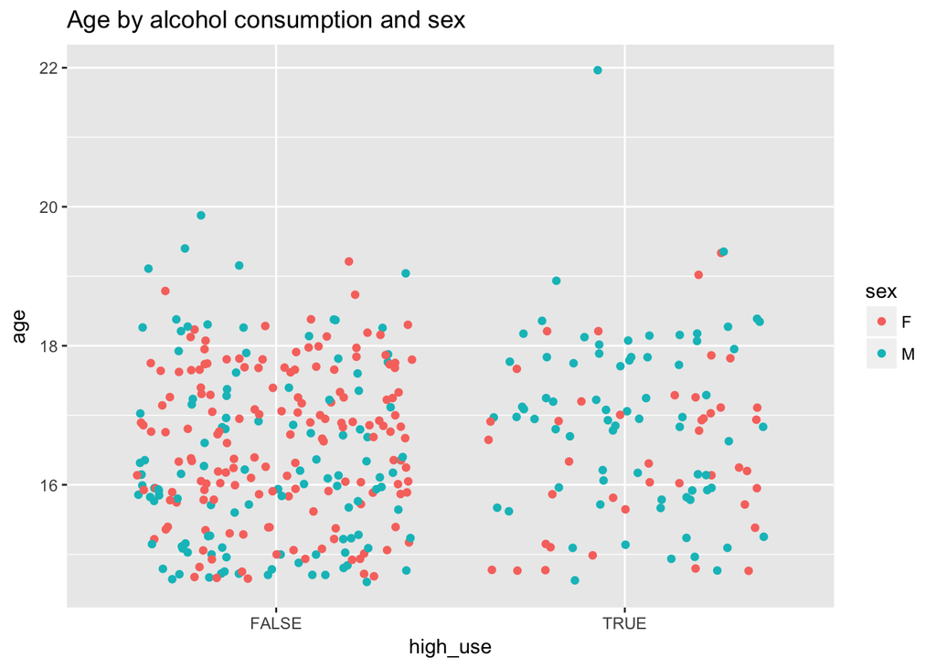

```r
#a jitterplot of high_use, sex and age
g1 <- ggplot(alc, aes(x = high_use, y = age, col = sex))
g1 + geom_jitter() + ggtitle("Age by alcohol consumption and sex")
```

It seems that there is randomnes of sex and age in both alcohol consumption groups.

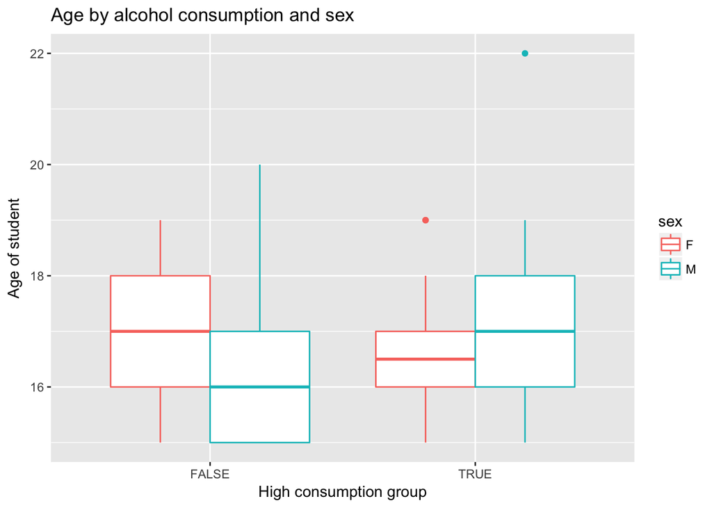

```r
#a boxplot of high_use, sex and age
g1 <- ggplot(alc, aes(x = high_use, y = age, col = sex))
g1 + geom_boxplot() + ggtitle("Age by alcohol consumption and sex") + xlab("High consumption group") + ylab("Age of student")
```

Means however show that young male students have lower mean of age in low consumption group and females in high consumption group.

**Study time**

High alcohol consumption may be related to time spend in studies because one can’t do both at the same time at least not successfully.

*H0: Alcohol consumption do not affect on weekly study time*

*H1: Alcohol consumption affects on weekly study time (numeric: 1 - <2 hours, 2 - 2 to 5 hours, 3 - 5 to 10 hours, or 4 - >10 hours)*

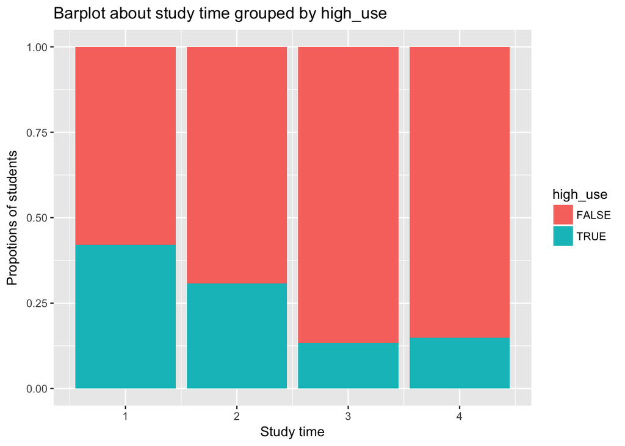

```r
#barplot about study time
ggplot(alc, aes(studytime, fill = high_use)) + geom_bar(position = "fill") +
  ggtitle("Barplot about study time grouped by high_use")+ xlab("Study time") + ylab("Propotions of students") + scale_y_continuous(name = waiver(), breaks = waiver(), minor_breaks = waiver(), labels = waiver(), limits = NULL, expand = waiver(), na.value = NA_real_, trans = "identity")
```

It seems that there is less high users in those students groups who spend more time in studying (3-4) than in those who spend less time in studying (1-2).

**Free time**

High alcohol consumption may be related to free time so that studets who have more free time are consuming more alcohol that studets who haven’t as much free time.

*H0: Amount of free time do not affect on alcohol consumption among students*

*H1: Amount of free time affects on alcohol consumption among students*

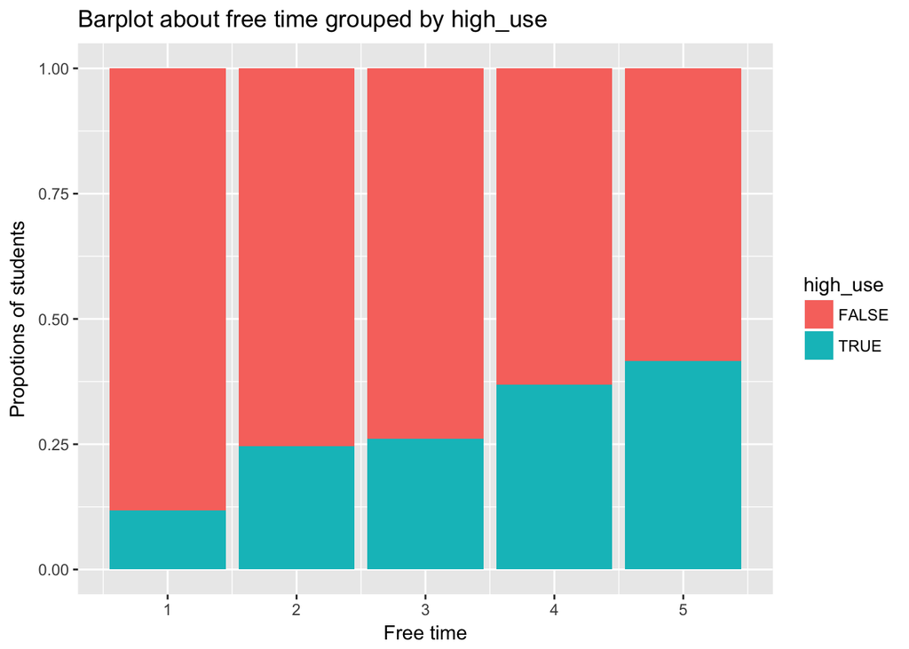

```r
#barplot about free time
ggplot(alc, aes(freetime, fill = high_use)) + geom_bar(position = "fill") +
  ggtitle("Barplot about free time grouped by high_use")+ xlab("Free time") + ylab("Propotions of students") + scale_y_continuous(name = waiver(), breaks = waiver(), minor_breaks = waiver(), labels = waiver(), limits = NULL, expand = waiver(), na.value = NA_real_, trans = "identity")
```

It seems that there are more students that are consuming alcohol high amounts in those students groups that have more free time than in those who have not as much free time.

**Absences**

High consumption of alcohol may cause absences.

*H0: High consumption of alcohol do not affect on absences*

*H1: High consumption of alcohol does affect on absences*

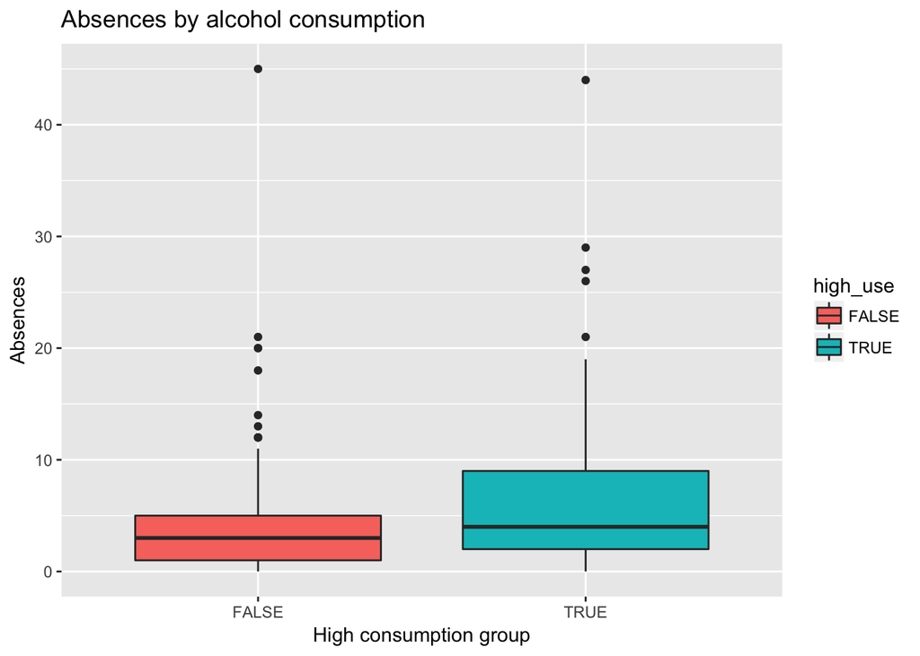

```r
#a boxplot of high_use and absences
g1 <- ggplot(alc, aes(x = high_use, y = absences, fill = high_use))
g1 + geom_boxplot() + ggtitle("Absences by alcohol consumption") + xlab("High consumption group") + ylab("Absences")
```

It seems that the differences between alcohol consumption groups in absences are small. Mean of absences is higher in high consumption group but it may not be significant.

## Logistic regression model

```r
#the model with glm()
m <- glm(high_use ~ age + studytime + freetime + absences, data = alc, family = "binomial")
summary(m)
```

```
##
## Call:
## glm(formula = high_use ~ age + studytime + freetime + absences,
##     family = "binomial", data = alc)
##
## Deviance Residuals:
##     Min       1Q   Median       3Q      Max
## -1.9649  -0.8267  -0.6238   1.0990   2.2861
##
## Coefficients:
##             Estimate Std. Error z value Pr(>|z|)
## (Intercept) -4.39240    1.79306  -2.450 0.014299 *
## age          0.18543    0.10313   1.798 0.072183 .
## studytime   -0.51842    0.15867  -3.267 0.001086 **
## freetime     0.33015    0.12430   2.656 0.007907 **
## absences     0.07856    0.02269   3.463 0.000535 ***
## ---
## Signif. codes:  0 '***' 0.001 '**' 0.01 '*' 0.05 '.' 0.1 ' ' 1
##
## (Dispersion parameter for binomial family taken to be 1)
##
##     Null deviance: 465.68  on 381  degrees of freedom
## Residual deviance: 423.18  on 377  degrees of freedom
## AIC: 433.18
##
## Number of Fisher Scoring iterations: 4
```

From the fitted model one can see that all explanatory variables except age are statistically significant with p-value < 0,01. Variable absence is also statistically sisgnificant with p-value < 0,001. It seems that age doesn’t explain whether or not a student is a high user of alcohol.

### Odds ratio and confidence intervals

```r
# compute odds ratios (OR)
OR <- coef(m) %>% exp
# compute confidence intervals (CI)
CI <- confint(m) %>% exp
# print out the odds ratios with their confidence intervals
cbind(OR, CI)
```

```
##                     OR        2.5 %    97.5 %
## (Intercept) 0.01237102 0.0003481843 0.3998333
## age         1.20373817 0.9852330457 1.4775972
## studytime   0.59545916 0.4321414645 0.8061535
## freetime    1.39118359 1.0938389338 1.7826010
## absences    1.08172440 1.0368164005 1.1336048
```

Odds ratio (OR) and the 95% confidence interval (CI) shows that those students who have a low study time are almost two times as likely to be a high user of alcohol than those studets who have higher study time. Students that have more freetime are also more likely to be a high user of alcohol. Also absences are positively correlated with high use of alcohol. Confidence interval shows that age is not statistically significant (because the interval contains 1) and other variables are.

### Predictive power of the model

Predictive power of the final logistic regression model is calculated without the statistically insignificant variable age.

```r
#the model with glm() and without the age variable
m_final <- glm(high_use ~ studytime + freetime + absences, data = alc, family = "binomial")
summary(m_final)
```

```
##
## Call:
## glm(formula = high_use ~ studytime + freetime + absences, family = "binomial",
##     data = alc)
##
## Deviance Residuals:
##     Min       1Q   Median       3Q      Max
## -1.9420  -0.8332  -0.6450   1.1266   2.1537
##
## Coefficients:
##             Estimate Std. Error z value Pr(>|z|)
## (Intercept) -1.34105    0.56337  -2.380 0.017293 *
## studytime   -0.50496    0.15691  -3.218 0.001290 **
## freetime     0.32626    0.12379   2.636 0.008401 **
## absences     0.08324    0.02262   3.680 0.000233 ***
## ---
## Signif. codes:  0 '***' 0.001 '**' 0.01 '*' 0.05 '.' 0.1 ' ' 1
##
## (Dispersion parameter for binomial family taken to be 1)
##
##     Null deviance: 465.68  on 381  degrees of freedom
## Residual deviance: 426.47  on 378  degrees of freedom
## AIC: 434.47
##
## Number of Fisher Scoring iterations: 4
```

```r
#predict and add the answer and the prediction to the data (alc)
probabilities <- predict(m_final, type = "response")
alc <- mutate(alc, probability = probabilities)
alc <- mutate(alc, prediction = probabilities > 0.5)

#tabulate the target variable versus the prediction
table("High use" = alc$high_use, "Prediction" = alc$prediction)
```

```
##         Prediction
## High use FALSE TRUE
##    FALSE   254   14
##    TRUE     93   21
```

```r
table("High use" = alc$high_use, "Prediction" = alc$prediction) %>% prop.table() %>% addmargins()
```

```
##         Prediction
## High use      FALSE       TRUE        Sum
##    FALSE 0.66492147 0.03664921 0.70157068
##    TRUE  0.24345550 0.05497382 0.29842932
##    Sum   0.90837696 0.09162304 1.00000000
```

Propabilities of the same table shows that over 28% are false predictions

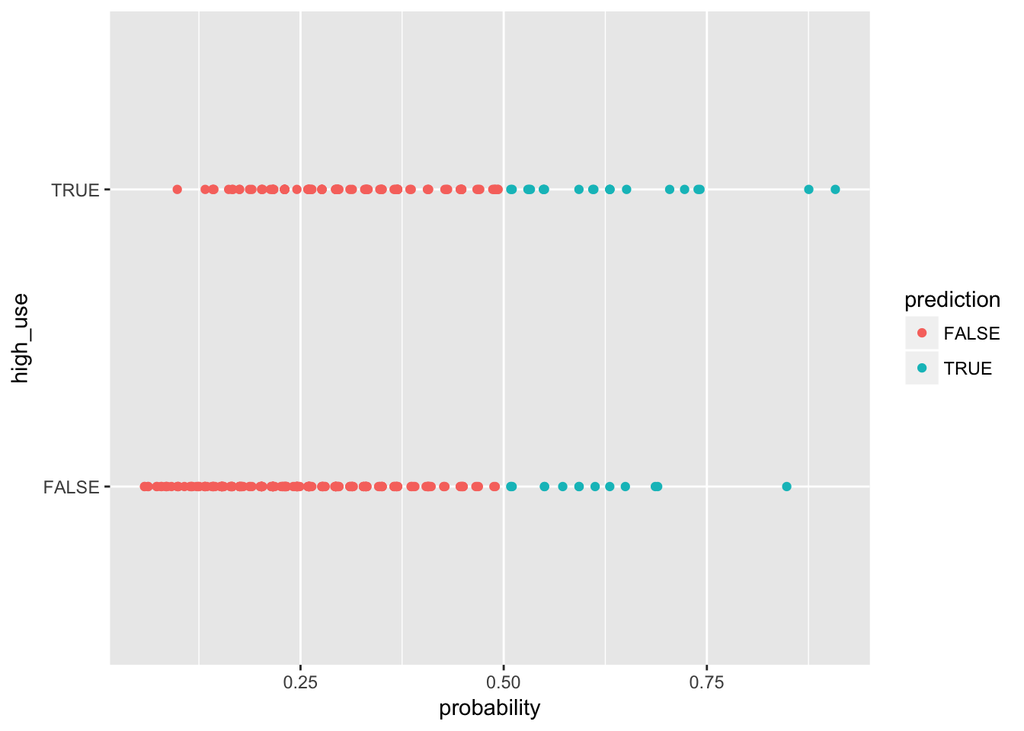

```r
#a plot of 'high_use' versus 'probability' in 'alc'
g <- ggplot(alc, aes(x = probability, y = high_use, col = prediction))
g + geom_point()
```

### Average number of wrong predictions

```r
#defining a loss function (mean prediction error)
loss_func <- function(class, prob) {
  n_wrong <- abs(class - prob) > 0.5
  mean(n_wrong)
}

#calling loss_func to compute the average number of wrong predictions in the (training) data
loss_func(class = alc$high_use, prob = alc$probability)
```

```
## [1] 0.2801047
```

The average number of wrong predictions is 28% by loss function

### Cross validation

```r
#computing the average number of wrong predictions in the (training) data
#loss_func(class = alc$high_use, prob = alc$probability)
#K-fold cross-validation
library(boot)
cv <- cv.glm(data = alc, cost = loss_func, glmfit = m_final, K = 10)
#average number of wrong predictions in the cross validation
cv$delta[1]
```

```
## [1] 0.2748691
```

10-fold cross-validation gives good estimate of the actual predictive power of the model. Low value = good.